# Assignment 3 - Text Mining

Author

Christian Navarro

## Due Date

This assignment is due by 11:59pm Pacific Time on Friday, November 7th, 2025.

## Text Mining

We have a USCbiostats repository for storing data called `data-science-data`. Navigate to the page for dataset `03_pubmed` (https://github.com/USCbiostats/data-science-data/tree/master/03_pubmed) and download the `pubmed.csv` dataset. This dataset contains 3,241 abstracts from articles collected via 5 PubMed searches. The search terms are listed in the second column, `term` and these will serve as the “documents.” Your job is to analyze these abstracts to find interesting insights.

```r
library(readr)
library(tidyverse)
library(tidytext)
library(textdata)
pubmed <- read_csv("~/Desktop/pubmed.csv")
```

1. (15 points) How many abstracts are associated with each search term? Tokenize the abstracts and count the number of each token. Do you see anything interesting? What are the 5 most common tokens for each search term?

```r
# Number of abstracts per search term
abstract_counts <- pubmed %>%
  count(term, name = "num_abstracts")
abstract_counts
```

```
# A tibble: 5 × 2
  term            num_abstracts
  <chr>                   <int>
1 covid                     981
2 cystic fibrosis           376
3 meningitis                317
4 preeclampsia              780
5 prostate cancer           787
```

```r
# Tokenize and count tokens
pubmed_tokens <- pubmed %>%
  unnest_tokens(word, abstract) %>%
  count(word, sort = TRUE)
head(pubmed_tokens, 20)
```

```
# A tibble: 20 × 2
   word         n
   <chr>    <int>
 1 the      28126
 2 of       24760
 3 and      19993
 4 in       14653
 5 to       10920
 6 a         8245
 7 with      8038
 8 covid     7275
 9 19        7080
10 is        5649
11 for       5492
12 patients  4674
13 cancer    3999
14 prostate  3832
15 was       3315
16 that      3226
17 were      3226
18 as        3159
19 this      3158
20 are       2833
```

```r
# 5 most common tokens for each search term
top_tokens_by_term <- pubmed %>%
  unnest_tokens(word, abstract) %>%
  group_by(term) %>%
  count(word, sort = TRUE) %>%
  slice_head(n = 5) %>%
  ungroup()
top_tokens_by_term
```

```
# A tibble: 25 × 3
   term            word      n
   <chr>           <chr> <int>
 1 covid           the    9741
 2 covid           of     7668
 3 covid           covid  7275
 4 covid           19     7035
 5 covid           and    6861
 6 cystic fibrosis the    2677
 7 cystic fibrosis of     2304
 8 cystic fibrosis and    1777
 9 cystic fibrosis in     1497
10 cystic fibrosis to     1011
# ℹ 15 more rows
```

Number of abstracts associated with each search term:

COVID: 981 abstracts

Prostate Cancer: 787 abstracts

Preeclampsia: 780 abstracts

Cystic Fibrosis: 376 abstracts

Meningitis: 317 abstracts

Token analysis reveals something interesting: The most common tokens across all search terms are dominated by common English stop words such as “the,” “of,” “and,” “in,” and “to.” This pattern indicates that without removing these generic words, the analysis fails to capture the meaningful medical terminology that distinguishes each search term.

Five most common tokens for each search term:

COVID: the (9,741), of (7,668), covid (7,275), 19 (7,035), and (6,861)

Cystic Fibrosis: the (2,677), of (2,304), and (1,777), in (1,497), to (1,011)

Meningitis: the (2,489), of (2,269), and (1,683), in (1,322), a (830)

Preeclampsia: the (7,119), of (6,837), and (5,255), in (3,869), to (2,651)

Prostate Cancer: the (6,100), of (5,682), and (4,417), cancer (3,840), prostate (3,832)

2. (15 points) Does removing stop words change what tokens appear as the most frequent? What are the 5 most common tokens for each search term after removing stop words?

```r
# Remove stop words and find 5 most common tokens for each term
top_tokens_no_stop <- pubmed %>%
  unnest_tokens(word, abstract) %>%
  anti_join(stop_words) %>%
  group_by(term) %>%
  count(word, sort = TRUE) %>%
  slice_head(n = 5) %>%
  ungroup()
top_tokens_no_stop
```

```
# A tibble: 25 × 3
   term            word         n
   <chr>           <chr>    <int>
 1 covid           covid     7275
 2 covid           19        7035
 3 covid           patients  2293
 4 covid           disease    943
 5 covid           pandemic   800
 6 cystic fibrosis fibrosis   867
 7 cystic fibrosis cystic     862
 8 cystic fibrosis cf         625
 9 cystic fibrosis patients   586
10 cystic fibrosis disease    400
# ℹ 15 more rows
```

Yes, removing stop words dramatically changes which tokens appear as most frequent. Instead of generic English words like “the,” “of,” and “and” dominating the results, we now see meaningful medical terminology that specifically characterizes each search term.

The 5 most common tokens for each search term after removing stop words:

COVID: covid (7,275), 19 (7,035), patients (2,293), disease (943), pandemic (800)

Cystic Fibrosis: fibrosis (867), cystic (862), cf (625), patients (586), disease (400)

Meningitis: patients (446), meningitis (429), meningeal (219), csf (206), clinical (187)

Preeclampsia: pre (2,038), eclampsia (2,005), preeclampsia (1,863), women (1,196), pregnancy (969)

Prostate Cancer: cancer (3,840), prostate (3,832), patients (934), treatment (926), disease (652)

The cleaned results now reveal domain-specific vocabulary that accurately reflects the medical focus of each search term.

3. (10 points) Tokenize the abstracts into bigrams. Find the 10 most common bigrams and visualize them.

```r
# Tokenize into bigrams and find 10 most common
top_bigrams <- pubmed %>%
  unnest_tokens(bigram, abstract, token = "ngrams", n = 2) %>%
  count(bigram, sort = TRUE) %>%
  slice_head(n = 10)

top_bigrams
```

```
# A tibble: 10 × 2
   bigram              n
   <chr>           <int>
 1 covid 19         6969
 2 of the           3883
 3 in the           3418
 4 prostate cancer  3222
 5 pre eclampsia    1854
 6 patients with    1587
 7 of covid         1519
 8 and the          1154
 9 to the           1061
10 of prostate       870
```

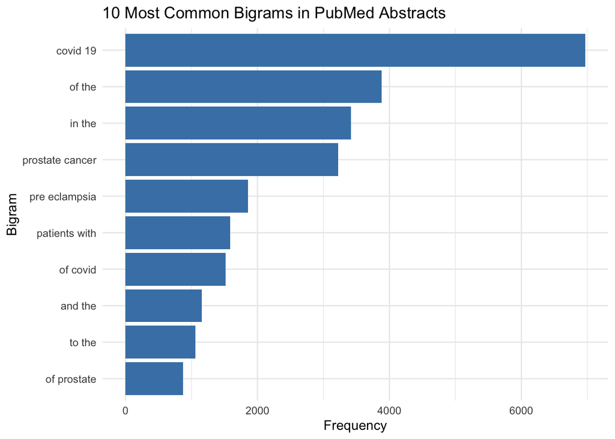

```r
# Visualize the top 10 bigrams
ggplot(top_bigrams, aes(x = n, y = fct_reorder(bigram, n))) +
  geom_col(fill = "steelblue") +
  labs(title = "10 Most Common Bigrams in PubMed Abstracts",
       x = "Frequency",
       y = "Bigram") +
  theme_minimal()
```

4. (20 points) Calculate the TF-IDF value for each word-search term combination (here you want the search term to be the “document”). What are the 5 tokens from each search term with the highest TF-IDF value? How are the results different from the answers you got in Question 1?

```r
# Calculate TF-IDF for each word-search term combination
tfidf_results <- pubmed %>%
  unnest_tokens(word, abstract) %>%
  count(term, word) %>%
  bind_tf_idf(word, term, n) %>%
  arrange(desc(tf_idf))

# Get 5 tokens with highest TF-IDF for each search term
top_tfidf <- tfidf_results %>%
  group_by(term) %>%
  slice_max(tf_idf, n = 5) %>%
  ungroup()

top_tfidf
```

```
# A tibble: 25 × 6
   term            word            n      tf   idf  tf_idf
   <chr>           <chr>       <int>   <dbl> <dbl>   <dbl>
 1 covid           covid        7275 0.0371  1.61  0.0597
 2 covid           pandemic      800 0.00408 1.61  0.00657
 3 covid           coronavirus   647 0.00330 1.61  0.00531
 4 covid           sars          372 0.00190 1.61  0.00305
 5 covid           cov           334 0.00170 1.61  0.00274
 6 cystic fibrosis cf            625 0.0127  0.916 0.0117
 7 cystic fibrosis fibrosis      867 0.0176  0.511 0.00901
 8 cystic fibrosis cystic        862 0.0175  0.511 0.00896
 9 cystic fibrosis cftr           86 0.00175 1.61  0.00282
10 cystic fibrosis sweat          83 0.00169 1.61  0.00272
# ℹ 15 more rows
```

COVID: covid, pandemic, coronavirus, sars, cov

Meningitis: meningitis, meningeal, pachymeningitis, csf, meninges

Preeclampsia: eclampsia, preeclampsia, pregnancy, maternal, gestational

Prostate Cancer: prostate, androgen, psa, prostatectomy, castration

## Sentiment Analysis

5. (20 points) Perform a sentiment analysis using the NRC lexicon. What is the most common sentiment for each search term? What if you remove `"positive"` and `"negative"` from the list?

```r
# Sentiment analysis with NRC lexicon
nrc_sentiments <- get_sentiments("nrc")

pubmed_sentiment <- pubmed %>%
  unnest_tokens(word, abstract) %>%
  inner_join(nrc_sentiments) %>%
  group_by(term) %>%
  count(sentiment, sort = TRUE) %>%
  slice_head(n = 1) %>%
  ungroup()
pubmed_sentiment
```

```
# A tibble: 5 × 3
  term            sentiment     n
  <chr>           <chr>     <int>
1 covid           positive   9874
2 cystic fibrosis positive   2747
3 meningitis      negative   2109
4 preeclampsia    positive   8014
5 prostate cancer negative   8918
```

```r
# Remove "positive" and "negative" from sentiment list
nrc_filtered <- nrc_sentiments %>%
  filter(!sentiment %in% c("positive", "negative"))

pubmed_sentiment_filtered <- pubmed %>%
  unnest_tokens(word, abstract) %>%
  inner_join(nrc_filtered) %>%
  group_by(term) %>%
  count(sentiment, sort = TRUE) %>%
  slice_head(n = 1) %>%
  ungroup()
pubmed_sentiment_filtered
```

```
# A tibble: 5 × 3
  term            sentiment        n
  <chr>           <chr>        <int>
1 covid           fear          7730
2 cystic fibrosis disgust       1714
3 meningitis      fear          1510
4 preeclampsia    anticipation  4780
5 prostate cancer fear          8118
```

Most common sentiment for each search term using the full NRC lexicon:

COVID: positive (9,874 occurrences)

Cystic Fibrosis: positive (2,747 occurrences)

Meningitis: negative (2,109 occurrences)

Preeclampsia: positive (8,014 occurrences)

Prostate Cancer: negative (8,918 occurrences)

Most common sentiment after removing “positive” and “negative” from the NRC lexicon:

COVID: fear (7,730 occurrences)

Cystic Fibrosis: disgust (1,714 occurrences)

Meningitis: fear (1,510 occurrences)

Preeclampsia: anticipation (4,780 occurrences)

Prostate Cancer: fear (8,118 occurrences)

The results show a dramatic shift when removing the broad “positive” and “negative” categories. COVID and prostate cancer research both show “fear” as the predominant specific emotion, reflecting the serious nature of these conditions. Meningitis shifts from “negative” to “fear,” while cystic fibrosis reveals “disgust” as its most common emotion. Interestingly, preeclampsia stands out with “anticipation” as its dominant sentiment, which may reflect the forward-looking nature of pregnancy-related research and monitoring.

6. (20 points) Now perform a sentiment analysis using the AFINN lexicon to get an average positivity score for each abstract (hint: you may want to create a variable that indexes, or counts, the abstracts). Create a visualization that shows these scores grouped by search term. Are any search terms noticeably different from the others?

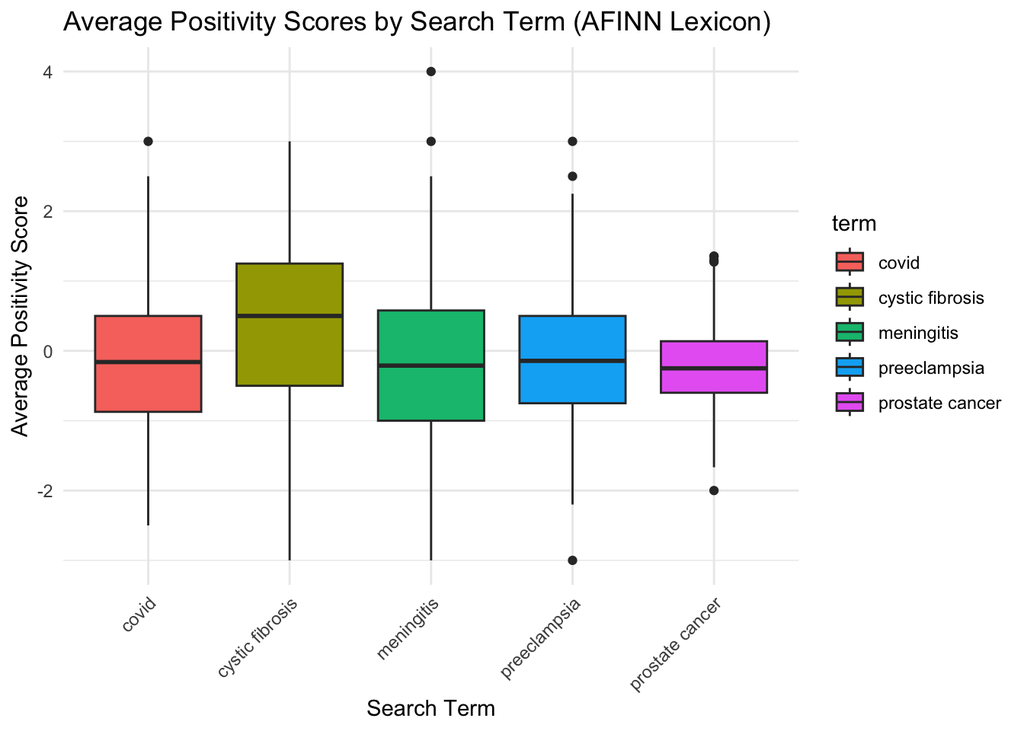

```r
# Get AFINN lexicon
afinn <- get_sentiments("afinn")

# Create abstract index and calculate average positivity score
pubmed_afinn <- pubmed %>%
  group_by(term) %>%
  mutate(abstract_id = row_number()) %>%
  ungroup() %>%
  unnest_tokens(word, abstract) %>%
  inner_join(afinn) %>%
  group_by(term, abstract_id) %>%
  summarize(positivity_score = mean(value), .groups = "drop")
# Create visualization
ggplot(pubmed_afinn, aes(x = term, y = positivity_score, fill = term)) +
  geom_boxplot() +
  labs(title = "Average Positivity Scores by Search Term (AFINN Lexicon)",
       x = "Search Term",
       y = "Average Positivity Score") +
  theme_minimal() +
  theme(axis.text.x = element_text(angle = 45, hjust = 1))
```

```r
# Calculate mean scores for comparison
mean_scores <- pubmed_afinn %>%
  group_by(term) %>%
  summarize(mean_positivity = mean(positivity_score)) %>%
  arrange(mean_positivity)

mean_scores
```

```
# A tibble: 5 × 2
  term            mean_positivity
  <chr>                     <dbl>
1 prostate cancer          -0.239
2 meningitis               -0.163
3 covid                    -0.147
4 preeclampsia             -0.121
5 cystic fibrosis           0.322
```

Based on the sentiment analysis using the AFINN lexicon:

The visualization shows the distribution of average positivity scores for each search term, and the calculated mean scores reveal clear differences between the medical conditions. Cystic fibrosis is noticeably different from all other search terms, with a positive average score of 0.32, while all other conditions have negative average scores.

The search terms can be ranked from most positive to most negative as follows: cystic fibrosis (0.32), preeclampsia (-0.12), covid (-0.15), meningitis (-0.16), and prostate cancer (-0.24). This suggests that cystic fibrosis research tends to use more positive language overall, possibly reflecting more hopeful treatment outcomes or research developments, whereas prostate cancer and meningitis research contain the most negative sentiment, which may correlate with the serious prognosis or challenging nature of these conditions.